# Project 1 - Data Analysis

Ramnivas Singh

02/28/2021

# Problem Statement

In this project, you’re given a text file with chess tournament results where the information has some structure. Your job is to create an R Markdown file that generates a .CSV file (that could for example be imported into a SQL database) with the following information for all of the players:  
Player’s Name, Player’s State, Total Number of Points, Player’s Pre-Rating, and Average Pre Chess Rating of opp_players  
For the first player, the information would be:  
Gary Hua, ON, 6.0, 1794, 1605  
1605 was calculated by using the pre-tournament opp_players’ ratings of 1436, 1563, 1600, 1610, 1649, 1663, 1716, and dividing by the total number of games played.

# Acceptance Criteria

- Source tournament data from remote location (GitHub)
- An R Markdown file that generates a .CSV file
- This file to be imported into a SQL database
- Average Pre Chess Rating of opp_players to be calculated
- This file to contain following information for all of the players:  
  Player’s Name, Player’s State, Total Number of Points, Player’s Pre-Rating, and Average Pre Chess Rating of opp_players
- Write .CSV file to remote location

# Analysis

- In the first record, Player Number, Player Name, Total Points, and the Round 1 - 7 results can be found.
- In the second record, Player’s State, USCF ID, Pre-Rating and Post-Rating values can be found.
- Remaining other fields not relevant for this project

# Approach

- Source tournament data from GitHub
- Parse tournament data to extract desired data
- Use regular expressions to extract the data
- Match players Id with opp_players Id
- Calculate average Pre Chess Rating of opp_players

# Implementation

## Source Data Set

```r
# Initial Setup - Load required libraries
library(tidyverse)
library(ggplot2)
library(DT)
library(dplyr)
library(htmltools)
```

Tournament data is located at remote location in a text file, top 4 lines are not relevant in the file so initil load will ignore these.

```r
# Load Raw tournament data
dataURL='https://raw.githubusercontent.com/rnivas2028/MSDS/Data607/Project1/tournamentinfo.txt'
tournament_results <- read.table(url(dataURL), skip=4, header = FALSE, sep = ",", strip.white=T)
head(tournament_results)
```

```
##                                                                                          V1
## 1     1 | GARY HUA                        |6.0  |W  39|W  21|W  18|W  14|W   7|D  12|D   4|
## 2    ON | 15445895 / R: 1794   ->1817     |N:2  |W    |B    |W    |B    |W    |B    |W    |
## 3 -----------------------------------------------------------------------------------------
## 4     2 | DAKSHESH DARURI                 |6.0  |W  63|W  58|L   4|W  17|W  16|W  20|W   7|
## 5    MI | 14598900 / R: 1553   ->1663     |N:2  |B    |W    |B    |W    |B    |W    |B    |
## 6 -----------------------------------------------------------------------------------------
```

Below regular expressions will be used to extract expected data set from tournament data load

```r
# To extract Pair Number
reg_ex_pair_num <- "\\d{1,2}(?=\\s\\|)"
# To extract Player's Name
reg_ex_player_name <- "\\w+[[:space:]]\\w+([[:space:]]\\w+)*"
# To extract Player's State
reg_ex_player_state <- "([[:upper:]]){2}\\s(?=\\|)"
# To extract Player's Point
reg_ex_players_point <- "\\d\\.\\d"
# To extract Player's Rating
reg_ex_pre_rating <- "(?<!\\>\\s)(?<=\\s{1,2}|\\s\\:)(\\d{3,4}(?=\\s|P))"
# To extract Player's opp_players
reg_ex_players_opp_players <- "(\\d{1,}|[[:blank:]]{1})(?=\\|)"
```

## Data Extraction

Chess tournament results are in textual format. Information extraction need parsing of row data and extraction or information using regular expressions. Below data points will be extracted from this data set:  
* Player’s Name  
* Player’s State  
* Total Number of Points  
* Player’s Pre-Rating

### Extract Player’s Name

This step will extract players name using regular expresssion, there are 64 players

```r
players <- unlist(str_extract_all(unlist(tournament_results), reg_ex_player_name))
```

### Extract Player’s State

This step will extract players name using regular expression, there are 64 players

```r
players_state <- unlist(str_extract_all(unlist(tournament_results), reg_ex_player_state))
```

Number of players from these states is below

```r
table(players_state)
```

```
## players_state
## MI  OH  ON
##  55   1   8
```

### Extract Player’s Point

Player’s Point is extracted in textual form and converted to numeric format

```r
players_point <- unlist(str_extract_all(unlist(tournament_results), reg_ex_players_point))
as.numeric(players_point)
```

```
##  [1] 6.0 6.0 6.0 5.5 5.5 5.0 5.0 5.0 5.0 5.0 4.5 4.5 4.5 4.5 4.5 4.0 4.0 4.0 4.0
## [20] 4.0 4.0 4.0 4.0 4.0 3.5 3.5 3.5 3.5 3.5 3.5 3.5 3.5 3.5 3.5 3.5 3.5 3.5 3.0
## [39] 3.0 3.0 3.0 3.0 3.0 3.0 3.0 3.0 2.5 2.5 2.5 2.5 2.5 2.5 2.0 2.0 2.0 2.0 2.0
## [58] 2.0 2.0 1.5 1.5 1.0 1.0 1.0
```

### Extract Pair Number

Pair Number is extracted in textual form and converted to numeric format

```r
pair_number <- unlist(str_extract_all(unlist(tournament_results), reg_ex_pair_num))
as.numeric(pair_number)
```

```
##  [1]  1  2  3  4  5  6  7  8  9 10 11 12 13 14 15 16 17 18 19 20 21 22 23 24 25
## [26] 26 27 28 29 30 31 32 33 34 35 36 37 38 39 40 41 42 43 44 45 46 47 48 49 50
## [51] 51 52 53 54 55 56 57 58 59 60 61 62 63 64
```

### Extract Player’s Pre Rating

Players pre rating is extracted in textual form and converted to numeric number

```r
players_pre_rating <- unlist(str_extract_all(unlist(tournament_results), reg_ex_pre_rating))
as.numeric(players_pre_rating)
```

```
##  [1] 1794 1553 1384 1716 1655 1686 1649 1641 1411 1365 1712 1663 1666 1610 1220
## [16] 1604 1629 1600 1564 1595 1563 1555 1363 1229 1745 1579 1552 1507 1602 1522
## [31] 1494 1441 1449 1399 1438 1355  980 1423 1436 1348 1403 1332 1283 1199 1242
## [46]  377 1362 1382 1291 1056 1011  935 1393 1270 1186 1153 1092  917  853  967
## [61]  955 1530 1175 1163
```

### Extract Player’s opp_players

Player’s opp_players are extracted using from given information in the file

```r
opp_players <- unlist(str_extract_all(unlist(tournament_results), reg_ex_players_opp_players))
```

### Extract Player’s opp_players

Player’s opp_players are extracted using from given information in the file

```r
# Extract and clean opponent players
opp_player1 <- as.numeric(opp_players[seq(4, length(opp_players), 10)])
opp_player1 <- as.numeric(opp_player1[seq(1, length(opp_player1), 2)])
opp_player2 <- as.numeric(opp_players[seq(5, length(opp_players), 10)])
opp_player2 <- as.numeric(opp_player2[seq(1, length(opp_player2), 2)])
opp_player3 <- as.numeric(opp_players[seq(6, length(opp_players), 10)])
opp_player3 <- as.numeric(opp_player3[seq(1, length(opp_player3), 2)])
opp_player4 <- as.numeric(opp_players[seq(7, length(opp_players), 10)])
opp_player4 <- as.numeric(opp_player4[seq(1, length(opp_player4), 2)])
opp_player5 <- as.numeric(opp_players[seq(8, length(opp_players), 10)])
opp_player5 <- as.numeric(opp_player5[seq(1, length(opp_player5), 2)])
opp_player6 <- as.numeric(opp_players[seq(9, length(opp_players), 10)])
opp_player6 <- as.numeric(opp_player6[seq(1, length(opp_player6), 2)])
opp_player7 <- as.numeric(opp_players[seq(10, length(opp_players), 10)])
opp_player7 <- as.numeric(opp_player7[seq(1, length(opp_player7), 2)])
# Create a matrix with opp_player information
opp_players <- matrix(c(opp_player1, opp_player2, opp_player3,
                    opp_player4, opp_player5, opp_player6, opp_player7),
                    nrow = 64, ncol = 7)
```

## Find average Pre Chess Rating of opp_players

Average Pre Chess Rating of opp_players is calculated by taking mean of opp_players Pre Chess Rating

```r
avg_pre_chess_rating <- 0
for (i in 1:(length(pair_number)))
{
  avg_pre_chess_rating[i] <- mean(as.numeric(players_pre_rating[opp_players[i,]]), na.rm = T)
}
```

## Create result data frame

Lets create a data frame with - Player’s Name, Player’s State, Total Number of Points, Player’s Pre-Rating, and Average Pre Chess Rating of opp_players

```r
tournament_data_result <- 0
tournament_data_result <- data.frame(players, players_state, players_point, players_pre_rating, avg_pre_chess_rating)
```

# Exploratory Data Analysis

Lets visualize tournament data results

Plot average pre chess rating with players points

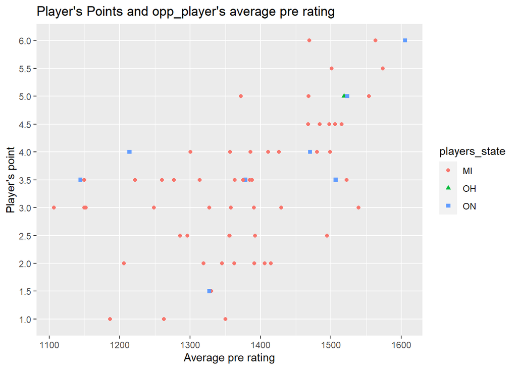

```r
ggplot(data = tournament_data_result,
       aes(x = avg_pre_chess_rating, y = players_point, color=players_state,
           shape=players_state)) +
  geom_point()+xlab("Average pre rating")+ylab("Player's point")+
  ggtitle("Player's Points and opp_player's average pre rating")
```

Plot Player count by state

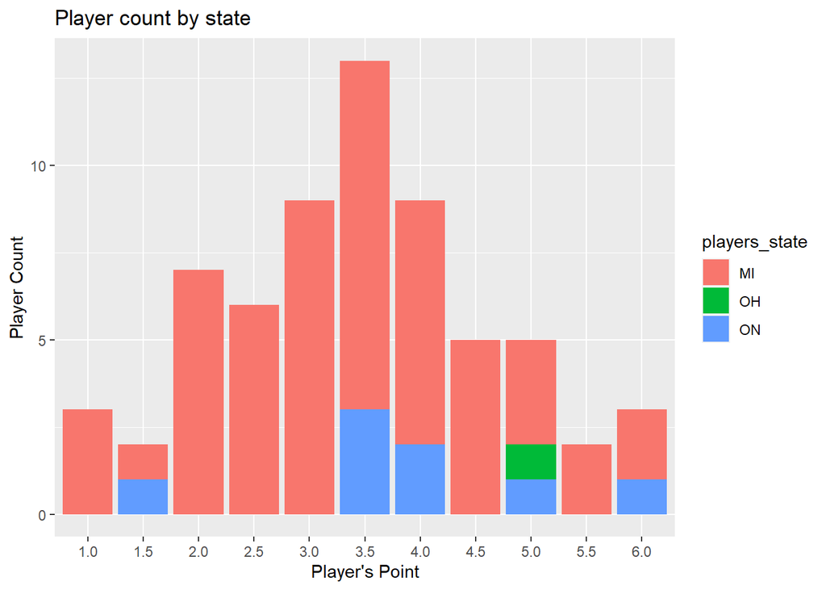

```r
ggplot(data = tournament_data_result) +
geom_bar(mapping = aes(x = players_point, fill = players_state))+
  xlab("Player's Point")+ylab("Player Count")+
  ggtitle("Player count by state")
```

- State MI has most of the players in this tournament
- ON is second with players count more than OH

Plot opp_players Average pre rating with Player’s point

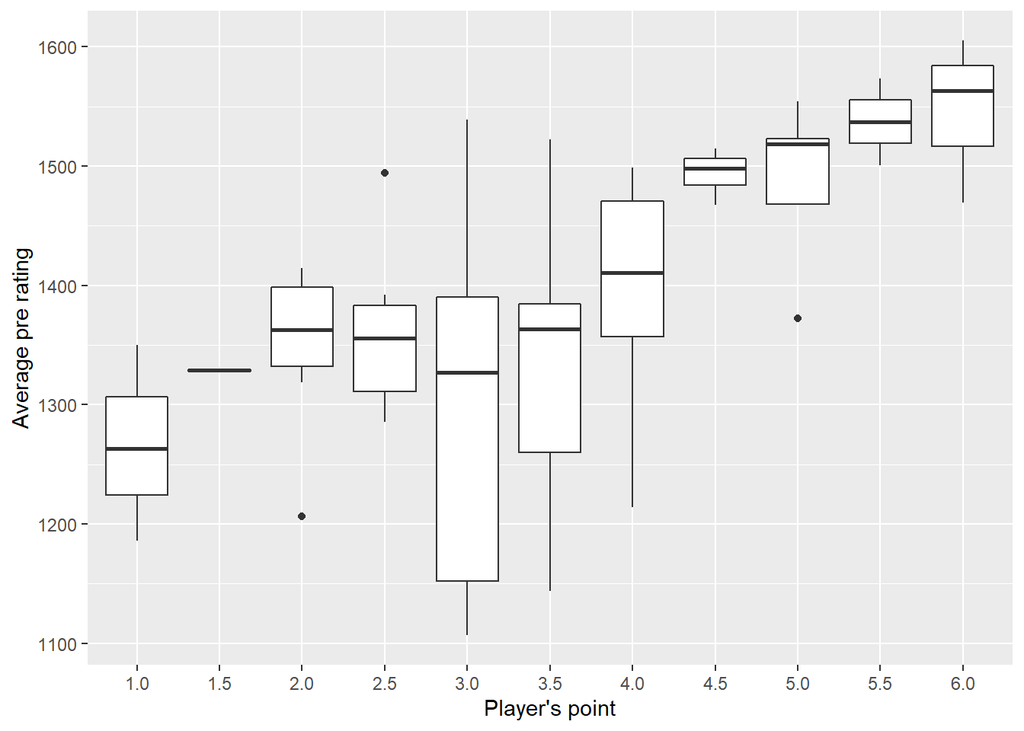

```r
ggplot(data = tournament_data_result, aes(x = players_point, y = avg_pre_chess_rating)) +
  geom_boxplot()+ylab("Average pre rating")+xlab("Player's point")
```

### Display result in a table

Create data table with search and navigation capabilities

```r
data_table<- data.frame(players, players_state, players_point, players_pre_rating,
                        round(avg_pre_chess_rating,2))
names(data_table)[0] <- "Player Id"
names(data_table)[1] <- "Name"
names(data_table)[2] <- "State"
names(data_table)[3] <- "Point"
names(data_table)[4] <- "Pre Rating"
names(data_table)[5] <- "Average Pre Rating of opp_players"
datatable(data_table, filter = 'bottom', options = list(pageLength = 10,
                                                        searching = FALSE,pageLength = TRUE))
```

|  | Name | State | Point | Pre Rating | Average Pre Rating of opp_players |
| --- | --- | --- | --- | --- | --- |
| 1 | GARY HUA | ON | 6.0 | 1794 | 1605.29 |
| 2 | DAKSHESH DARURI | MI | 6.0 | 1553 | 1469.29 |
| 3 | ADITYA BAJAJ | MI | 6.0 | 1384 | 1563.57 |
| 4 | PATRICK H SCHILLING | MI | 5.5 | 1716 | 1573.57 |
| 5 | HANSHI ZUO | MI | 5.5 | 1655 | 1500.86 |
| 6 | HANSEN SONG | OH | 5.0 | 1686 | 1518.71 |
| 7 | GARY DEE SWATHELL | MI | 5.0 | 1649 | 1372.14 |
| 8 | EZEKIEL HOUGHTON | MI | 5.0 | 1641 | 1468.43 |
| 9 | STEFANO LEE | ON | 5.0 | 1411 | 1523.14 |
| 10 | ANVIT RAO | MI | 5.0 | 1365 | 1554.14 |

[output cut: 54 more lines]

## Write result set to a file

This step will write result data to a .CSV file

```r
write.csv(tournament_data_result, file = "tournament_data_result.csv")
```

# Additional implementation

These instructions can be used to import .CSV file into MySQL database

## Create database

```
DROP DATABASE IF EXISTS movie_ratings;
CREATE DATABASE `tournament_data_results`
USE tournament_data_results;
```

## Create a table

```
DROP TABLE IF EXISTS tournament_result;
CREATE TABLE `tournament_result` (
  `player_id` int NOT NULL,
  `player_name` varchar(100) DEFAULT NULL,
  `players_state` varchar(10) DEFAULT NULL,
  `players_point` float(10,2) DEFAULT NULL,
  `players_pre_rating` float(10,2) DEFAULT NULL,
  `avg_pre_chess_rating` float(10,2) DEFAULT NULL,
  `addedOn` datetime DEFAULT NULL,
  `addedBy` varchar(100) DEFAULT NULL,
  `updatedOn` datetime DEFAULT NULL,
  `updatedBy` varchar(100) DEFAULT NULL,
  PRIMARY KEY (`player_id`)
);
```

## Importing data

```
LOAD DATA INFILE '<<File Location>>\\tournament_data_results.csv'
INTO TABLE tournament_result
FIELDS TERMINATED BY ','
ENCLOSED BY '"'
LINES TERMINATED BY '\n'
IGNORE 1 ROWS;
```

## Using AWS S3

- Using AWS S3 to export .CSV file for future use cases is recommended capability
- AWS S3 is industry standard to retain data files to access from anywhere on internet

```r
library (readr)
library(aws.s3)
bucketlist(key = <AWS Key>, secret = <AWS Key>)
# Upload files to S3 bucket
put_object(
  file = file.path(tempdir(), "tournament_data_result.csv"),
  object = "tournament_data_result.csv",
  bucket = "msds-data607"
)
# Get buckets and contents
get_bucket(bucket = "msds-data607")

# Display contents
s3read_using(FUN = read.csv, bucket = "msds-data607", object = "tournament_data_result.csv")
s3read_using(FUN = read.csv, object = "s3://msds-data607/tournament_data_result.csv")
s3read_using(FUN = data.table::tournament_data_result,
             object = "s3://msds-data607/tournament_data_result.csv")
```

# Conclusion

- Regular expressions are extremely useful to extract desired data set from textual contents
- Data can be cleansed and used for further analysis such as calculating average pre ratings of opp_players
- Refined data set can be used to render for visual display or save in a file process further in relational database
- Output data file can also be saved to AWS S3 bucket. An additional library (aws.s3) needed in R to get this working